# 1、Retrieval模块的设计意义

Retrieval直接翻译过来即“检索”，本章Retrieval模块包括与检索步骤相关的所有内容，例如数据的获取、切分、向量化、向量存储、向量检索等模块。

## 1.1 大模型的局限

### 1）知识滞后

LLM 训练数据有截止日期，无法及时反映最新的信息或动态变化。比如：难以应对诸如“请推荐当前热门影片”等时间敏感性问题。

### 2）知识缺失

大型语言模型（LLM）的训练依赖于网络上海量公开的静态数据，而某些特定领域（如企业内部资料、专有技术文档等）或你的私有数据是缺乏的，导致模型回复时生成不准确甚至虚构的回复。

### 3）幻觉

LLM 在生成回答时，可能会“胡言乱语” ，这种现象称之为 LLM 的“幻觉”。“幻觉”可以体现为错误陈述、编造事实、错误的复杂推理或者复杂语境下理解能力不足等。  
**幻觉问题的严重性：** 大模型生成内容的不可控，尤其是在金融和医疗领域等领域， 一次金额评估的错误，一次医疗诊断的失误，哪怕只出现一次都是致命的。但，对于非专业人士来说可能难以辨识。目前还没有能够百分之百解决这种情况的方案。  
**幻觉产生的原因：**

- 训练知识存在偏差，这些错误信息被 LLM 学习后在输出中复现
- LLM 训练时过度泛化，将普通的模式应用在特定场合导致不准确输出
- LLM 本身没有真正学习到训练数据中深层次的含义，导致在一些需要深入理解或复杂推理的任务中出错
- LLM 缺乏某些领域的相关知识，在面临这些领域的相关问题时编造不存在的信息

**当前大家普遍达成共识的一个方案：**  
首先，为大模型提供一定的上下文信息，让其输出会变得更稳定。  
其次，利用本章的RAG，将检索出来的文档和提示词输送给大模型，生成更可靠的答案。

## 1.2 什么是RAG

RAG（Retrieval-Augmented Generation，检索增强生成）是一种结合信息检索（Retrieval）与文本生成（Generation）的技术，旨在提升大语言模型在回答专业问题时的准确性和可靠性。  
典型的检索流程如下：（官方）

[figure not shown]

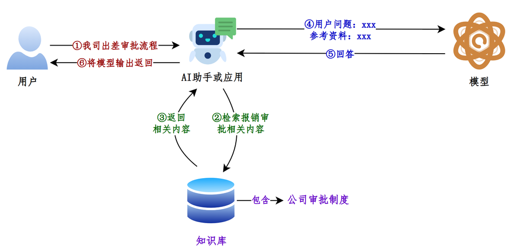

> 如果说LangChain相当于给LLM这个“大脑”安装了“四肢和躯干”，RAG则是为LLM提供了接入“人类知识图书馆”的能力。

RAG的项目举例：  
目前，已经出现了非常多的产品几乎完全建立在 RAG 之上，包括客服系统、基于大模型的数据分析，以及成千上万的数据驱动聊天应用，应用场景五花八门。

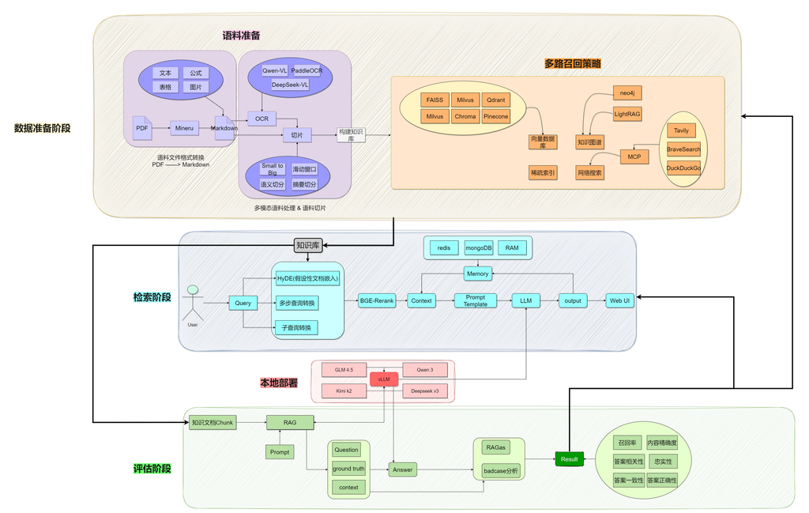

[figure not shown]

[figure not shown]

## 1.3 RAG优缺点

### RAG的优点

1）相比提示词工程，RAG有更丰富的上下文和数据样本，可以不需要用户提供过多的背景描述，就能生成比较符合用户预期的答案。  
2）相比于模型微调，RAG可以提升问答内容的时效性和可靠性  
3）在一定程度上保护了业务数据的隐私性。

### RAG的缺点

1）由于每次问答都涉及外部系统数据检索，因此RAG的响应时延相对较高。  
2）引用的外部知识数据会消耗大量的模型Token 资源。

## 1.4 RAG工作流程

[figure not shown]

### 环节1：Source（数据源）

指的是RAG架构中所外挂的知识库。这里有三点说明：  
1、原始数据源类型多样：如：视频、图片、文本、代码、文档等  
2、形式的多样性：

- 可以是上百个.csv文件，可以是上千个.json文件，也可以是上万个.pdf文件
- 可以是某一个业务流程外放的API，可以是某个网站的实时数据等

### 环节2：Load（加载）

文档加载器（Document Loaders）负责将来自不同数据源的非结构化文本，加载到内存，成为文档(Document)对象。  
文档对象包含文档内容和相关元数据信息，例如TXT、CSV、HTML、JSON、Markdown、PDF，甚至 YouTube 视频转录等。

文档加载器还支持“ 延迟加载”模式，以缓解处理大文件时的内存压力。  
LangChain封装好的loader地址：https://docs.langchain.com/oss/python/integrations/document_loaders  
文档加载器的编程接口使用起来非常简单，以下给出加载TXT格式文档的例子。

```python
from langchain.document_loadersimport TextLoader

loader = TextLoader("./test.txt")
print(loader.load())
```

### 环节3：Transform（转换）

文档转换器(Document Transformers) 负责对加载的文档进行转换和处理，以便更好地适应下游任务的需求。  
文档转换器提供了一致的接口（工具）来操作文档，主要包括以下几类：

- 文本拆分器(Text Splitters) ：将长文本拆分成语义上相关的小块，以适应语言模型的上下文窗口限制。
- 冗余过滤器(Redundancy Filters) ：识别并过滤重复的文档。
- 元数据提取器(Metadata Extractors) ：从文档中提取标题、语调等结构化元数据。
- 多语言转换器(Multi-lingual Transformers) ：实现文档的机器翻译。
- 对话转换器(Conversational Transformers) ：将非结构化对话转换为问答格式的文档。

总的来说，文档转换器是 LangChain 处理管道中非常重要的一个组件，它丰富了框架对文档的表示和操作能力。  
在这些功能中，文档拆分器是必须的操作。下面单独说明。

#### 环节3.1：Text Splitting（文档拆分）

- 拆分/分块的必要性：前一个环节加载后的文档对象可以直接传入文档拆分器进行拆分，而文档切块后才能向量化并存入数据库中。
- 文档拆分器的多样性：LangChain提供了丰富的文档拆分器，不仅能够切分普通文本，还能切分Markdown、JSON、HTML、代码等特殊格式的文本。
- 拆分/分块的挑战性：实际拆分操作中需要处理许多细节问题， 不同类型的文本、不同的使用场景都需要采用不同的分块策略。（具体策略见2.3.2）

**在构建RAG应用程序的整个流程中，拆分/分块是最具挑战性的环节之一，它显著影响检索效果。** 目前还没有通用的方法可以明确指出哪一种分块策略最为有效。不同的使用场景和数据类型都会影响分块策略的选择。

### 环节4：Embed（嵌入）

文档嵌入模型（Text Embedding Models）负责将文本转换为向量表示，即模型赋予了文本计算机可理解的数值表示，使文本可用于向量空间中的各种运算，大大拓展了文本分析的可能性，是自然语言处理领域非常重要的技术。

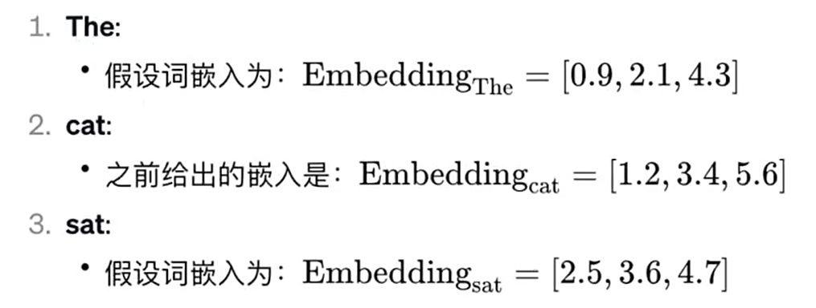

实现原理：通过特定算法（如Word2Vec）将语义信息编码为固定维度的向量，具体算法细节需后续深入。 关键特性：相似的词在向量空间中距离相近，例如"猫"和"犬"的向量夹角小于"猫"和"汽车"。

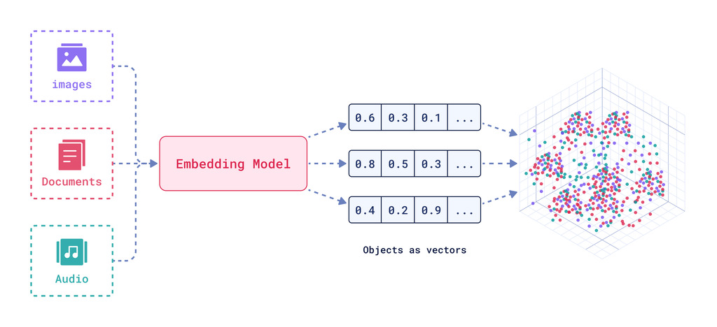

文本嵌入为 LangChain 中的问答、检索、推荐等功能提供了重要支持。具体为：

- 语义匹配：通过计算两个文本的向量余弦相似度，判断它们在语义上的相似程度，实现语义匹配。
- 文本检索：通过计算不同文本之间的向量相似度，可以实现语义搜索，找到向量空间中最相似的文本。
- 信息推荐：根据用户的历史记录或兴趣嵌入生成用户向量，计算不同信息的向量与用户向量的相似度，推荐相似的信息。
- 知识挖掘：可以通过聚类、降维等手段分析文本向量的分布，发现文本之间的潜在关联，挖掘知识。
- 自然语言处理：将词语、句子等表示为稠密向量，为神经网络等下游任务提供输入。

### 环节5：Store（存储）

LangChain 还支持把文本嵌入存储到向量存储或临时缓存，以避免需要重新计算它们。这里就出现了数据库，支持这些嵌入的高效存储和搜索的需求。

[figure not shown]

### 环节6：Retrieve（检索）

检索器（Retrievers）是一种用于响应非结构化查询的接口，它可以返回符合查询要求的文档。  
LangChain 提供了一些常用的检索器，如向量检索器、文档检索器、网站研究检索器等。  
通过配置不同的检索器，LangChain 可以灵活地平衡检索的精度、召回率与效率。检索结果将为后续的问答生成提供信息支持，以产生更加准确和完整的回答。

# 2、详细使用流程

## 2.1 环境准备

### 2.1.1 安装依赖

检查冲突 pip check

### 2.1.2 准备数据

将 knowledge.txt 置于项目根目录下  
将 asset文件夹 解压后置于项目根目录下

## 2.2 文档加载器 Document Loaders

数据源可能包含多种格式的文件，如文本文档、Markdown，PDF 等。LangChain 实现和集成了众多文档加载器（https://docs.langchain.com/oss/python/integrations/document_loaders ），方便从不同格式的文件中加载数据。

**常用 Loaders：**

- TextLoader - 文本文件
- CSVLoader - CSV 文件
- PyPDFLoader - PDF 文件
- WebBaseLoader - 网页

LangChain的设计：对于Source 中多种不同的数据源，我们可以用一种统一的形式读取、调用。上述每一个文档加载器，都要继承自 BaseLoader 基类，此类提供了通用的 load （一次加载所有文档）与 lazy_load （以延迟方式加载文档） 方法，用于从数据源加载数据并处理为Document 对象。

### 2.2.1 加载txt

```python
# 1.导入相关依赖
from langchain_community.document_loaders import TextLoader
# 2.定义TextLoader对象，file_path=".txt的位置"
text_loader = TextLoader(file_path="./asset/load/01-langchain-utf-8.txt",encoding="utf-8")
# 3.加载
docs = text_loader.load() #返回List列表(Document对象)
# 4.打印
print(docs)
```

```
[Document(metadata={'source': './asset/load/01-langchain-utf-8.txt'}, page_content='LangChain 是一个**开源的 Python/JavaScript 框架**，核心目标是**简化大语言模型（LLM）应用的开发**——它把 LLM、外部工具（搜索、数据库、代码执行）、数据来源（文档、API）、记忆能力（上下文存储）等模块“串联”起来，让你不用从零开发就能快速构建智能体（Agent）、检索增强生成（RAG）、对话机器人等复杂 LLM 应用。')]
```

Documment对象中有两个重要的属性：

- page_content：真正的文档内容，字符串类型。
- metadata：文档内容的原数据，字典类型。

```python
print(type(docs[0])) #langchain_core.documents.base.Document
print(docs[0].page_content)
```

```
<class 'langchain_core.documents.base.Document'>
LangChain 是一个**开源的 Python/JavaScript 框架**，核心目标是**简化大语言模型（LLM）应用的开发**——它把 LLM、外部工具（搜索、数据库、代码执行）、数据来源（文档、API）、记忆能力（上下文存储）等模块“串联”起来，让你不用从零开发就能快速构建智能体（Agent）、检索增强生成（RAG）、对话机器人等复杂 LLM 应用。
```

```python
print(docs[0].metadata) # {'source': './data/langchain.txt'}
```

```
{'source': './asset/load/01-langchain-utf-8.txt'}
```

### 2.2.2 加载CSV

举例：加载csv所有列

```python
from langchain_community.document_loaders.csv_loader import CSVLoader
loader = CSVLoader(file_path=r"C:\Users\huan.zheng\myproject\LangChainLearning\LangChain1+\asset\load\03-load.csv", encoding="gbk")
data = loader.load()
print(data)

print(type(data)) # <class 'list'>
print(type(data[0])) # <class 'langchain_core.documents.base.Document'>
print(len(data)) # 4
print(data[0].page_content) # id: 1 title: Introduction to Python ...
```

```
[Document(metadata={'source': 'C:\\Users\\huan.zheng\\myproject\\LangChainLearning\\LangChain1+\\asset\\load\\03-load.csv', 'row': 0}, page_content='模块: Models\n作用: 集成各类 LLM（OpenAI、Anthropic、国产大模型）、聊天模型（ChatOpenAI）'), Document(metadata={'source': 'C:\\Users\\huan.zheng\\myproject\\LangChainLearning\…
<class 'list'>
<class 'langchain_core.documents.base.Document'>
7
模块: Models
作用: 集成各类 LLM（OpenAI、Anthropic、国产大模型）、聊天模型（ChatOpenAI）
```

### 2.2.3 加载JSON

LangChain提供的JSON格式的文档加载器是JSONLoader 。在实际应用场景中，JSON格式的数据占有很大比例，而且JSON的形式也是多样的。我们需要特别关注。  
JSONLoader 使用指定的 jq结构来解析 JSON 文件。jq是一个轻量级的命令行 JSON 处理器 ，可以对JSON 格式的数据进行各种复杂的处理，包括数据过滤、映射、减少和转换，是处理 JSON 数据的首选工具之一。

需要 pip install jq

常见 jq schema 参考：

```python
JSON -> ["...", "...", "..."]
jq_schema -> ".[]"

JSON -> [{"text": ...}, {"text": ...}, {"text": ...}]
jq_schema -> ".[].text"

JSON -> {"key": [{"text": ...}, {"text": ...}, {"text": ...}]}
jq_schema -> ".key[].text"
```

详细用法可参考 [https://jqlang.org/manual/#basic-filters。](https://jqlang.org/manual/#basic-filters%E3%80%82)

#### 举例1：使用JSONLoader文档加载器加载

```python
# 1.导入依赖
from langchain_community.document_loaders import JSONLoader
from rich import print as rprint

# 2.定义JSONLoader对象
# 情况1
json_loader=JSONLoader(
    file_path="../LangChain1+/asset/load/04-load.json",
    jq_schema=".", ## 提取所有字段
    text_content=False #保持原始 JSON 结构，将提取的数据转换为JSON字符串存入page_content字段中
)

# 情况2
# .messages[].content:遍历.messages[]中所有元素 从每一个元素中提取.content字段
# json_loader=JSONLoader(
    # file_path="../asset/load/03-load.json",
    # jq_schema=".messages[].content"
# )

# 3.加载
docs = json_loader.load()
rprint(docs)
```

```
[
    Document(
        metadata={
            'source':
'C:\\Users\\huan.zheng\\myproject\\LangChainLearning\\LangChain1+\\asset\\load\\04-load.json',
            'seq_num': 1
        },
        page_content='{"employees": [{"id": "EMP001", "name": "\\u5f20\\u4e09", "age": 32, "gender": "\\u7537",
"department": "\\u6280\\u672f\\u90e8", "position": "\\u540e\\u7aef\\u5f00\\u53d1\\u5de5\\u7a0b\\u5e08",
"entry_date": "2020-05-10"}, {"id": "EMP002", "name": "\\u674e\\u56db", "age": 28, "gender": "\\u5973",
"department": "\\u5e02\\u573a\\u90e8", "position": "\\u5e02\\u573a\\u4e13\\u5458", "entry_date": "2021-08-15"},
{"id": "EMP003", "name": "\\u738b\\u4e94", "age": 40, "gender": "\\u7537", "department": "\\u7ba1\\u7406\\u5c42",
"position": "\\u6280\\u672f\\u603b\\u76d1", "entry_date": "2018-01-02"}, {"id": "EMP004", "name": "\\u8d75\\u516d",
"age": 26, "gender": "\\u5973", "department": "\\u4eba\\u4e8b\\u90e8", "position": "HR\\u52a9\\u7406",
"entry_date": "2022-03-22"}]}'
    )
]
```

#### 举例2：提取04-response.json文件中指定的文本

##### 加载json文件中所有的数据

```python
from langchain_community.document_loaders import JSONLoader
from rich import print as rprint
json_loader = JSONLoader(
    file_path="./asset/load/04-load.json",
    jq_schema=".", #指定jq_schema参数为.，表示加载整个json文件作为一个Document对象
    text_content=False #将加载的json对象转换为json字符串，作为Document对象的page_content属性值
)

docs = json_loader.load()
rprint(docs)
```

```
[
    Document(
        metadata={
            'source':
'C:\\Users\\huan.zheng\\myproject\\LangChainLearning\\LangChain1+\\asset\\load\\04-load.json',
            'seq_num': 1
        },
        page_content='{"employees": [{"id": "EMP001", "name": "\\u5f20\\u4e09", "age": 32, "gender": "\\u7537",
"department": "\\u6280\\u672f\\u90e8", "position": "\\u540e\\u7aef\\u5f00\\u53d1\\u5de5\\u7a0b\\u5e08",
"entry_date": "2020-05-10"}, {"id": "EMP002", "name": "\\u674e\\u56db", "age": 28, "gender": "\\u5973",
"department": "\\u5e02\\u573a\\u90e8", "position": "\\u5e02\\u573a\\u4e13\\u5458", "entry_date": "2021-08-15"},
{"id": "EMP003", "name": "\\u738b\\u4e94", "age": 40, "gender": "\\u7537", "department": "\\u7ba1\\u7406\\u5c42",
"position": "\\u6280\\u672f\\u603b\\u76d1", "entry_date": "2018-01-02"}, {"id": "EMP004", "name": "\\u8d75\\u516d",
"age": 26, "gender": "\\u5973", "department": "\\u4eba\\u4e8b\\u90e8", "position": "HR\\u52a9\\u7406",
"entry_date": "2022-03-22"}]}'
    )
]
```

##### 加载json文件中employees[]中的name字段

```python
from langchain_community.document_loaders import JSONLoader

json_loader = JSONLoader(
    file_path="./asset/load/04-load.json",
    jq_schema=".employees[].name", #加载json文件中employees[]中的name字段
    #text_content=False #将加载的json对象转换为json字符串，作为Document对象的page_content属性值,(如果内容本身就是字符串，则不用这个参数)
)

docs = json_loader.load()
for doc in docs:
    print(doc.page_content)
```

```
张三
李四
王五
赵六
```

##### 提取04-response.json文件中嵌套在data.items[].content的文本

```python
from langchain_community.document_loaders import JSONLoader
# 方式1
json_loader = JSONLoader(
    file_path="./asset/load/04-response.json",
    jq_schema=".data[].items[].content", #加载json文件中data[]中的content字段
    #text_content=False #将加载的json对象转换为json字符串，作为Document对象的page_content属性值,(如果内容本身就是字符串，则不用这个参数)
)

docs = json_loader.load()
for doc in docs:
    print(doc.page_content)
```

```
本教程从Python环境搭建开始，手把手教你掌握变量、数据类型、循环等基础语法，适合纯新手学习。
JSON是轻量级数据交换格式，本文讲解JSON的语法规则、嵌套结构、与Python的交互方法，附实战案例。
教程太实用了，跟着学完已经能写简单的爬虫脚本了！
JSON嵌套这块一直没搞懂，看了文章终于理清思路了，感谢作者！
学习总结：1. JSON键名必须用双引号；2. 嵌套数组用[]；3. content字段存储核心文本内容。
```

```python
from langchain_community.document_loaders import JSONLoader
# 方式2
json_loader = JSONLoader(
    file_path="./asset/load/04-response.json",
    jq_schema=".data[].items[]", #加载json文件中data[]中的content字段
    content_key=".content", #指定content_key参数为content，表示将json对象中的content字段作为Document对象的page_content属性值
    is_content_key_jq_parsable=True #用jq解析content_key参数指定的content字段，获取content字段的值作为Document对象的page_content属性值
    )

docs = json_loader.load()
for doc in docs:
    print(doc.page_content)
```

```
本教程从Python环境搭建开始，手把手教你掌握变量、数据类型、循环等基础语法，适合纯新手学习。
JSON是轻量级数据交换格式，本文讲解JSON的语法规则、嵌套结构、与Python的交互方法，附实战案例。
教程太实用了，跟着学完已经能写简单的爬虫脚本了！
JSON嵌套这块一直没搞懂，看了文章终于理清思路了，感谢作者！
学习总结：1. JSON键名必须用双引号；2. 嵌套数组用[]；3. content字段存储核心文本内容。
```

##### 提取04-response.json文件中嵌套在data.items[]里的title、content和其文本

```python
# 1.导入相关依赖
from langchain_community.document_loaders import JSONLoader
from pprint import pprint

# 2.定义json文件的路径
file_path = 'asset/load/04-response.json'

loader = JSONLoader(
    file_path=file_path,
    # jq_schema=".data.items[] | {id, author, text: (.title + '\n' + .content)}",
    jq_schema=".data[].items[]",
    content_key='.title + "\\n" + .content', # 将title和content字段的值拼接起来作为Document对象的page_content属性值
    is_content_key_jq_parsable=True # 用jq解析content_key
)

# 4.加载
data = loader.load()
for doc in data:
    print("\n"+doc.page_content)
```

```
Python零基础入门教程
本教程从Python环境搭建开始，手把手教你掌握变量、数据类型、循环等基础语法，适合纯新手学习。

JSON数据格式详解
JSON是轻量级数据交换格式，本文讲解JSON的语法规则、嵌套结构、与Python的交互方法，附实战案例。


教程太实用了，跟着学完已经能写简单的爬虫脚本了！


JSON嵌套这块一直没搞懂，看了文章终于理清思路了，感谢作者！


学习总结：1. JSON键名必须用双引号；2. 嵌套数组用[]；3. content字段存储核心文本内容。
```

### 2.2.4 加载pdf

PDF 存在多种来源格式，包括扫描版（图片 PDF）、电子文本版、混合版。并且布局格式也多种多样，包括单列布局、双列布局甚至竖排文本布局。并且包含段落、标题、页眉页脚、表格、数学公式、化学式、特殊符号、图片等各种元素。  
因此，PDF 解析存在很多挑战。对于复杂 PDF，需要进行文本提取、布局检测、表格解析、公式识别等处理。

#### 方式1：PyPDFLoader

LangChain加载PDF文件使用的是pypdf，先安装pip install pypdf

```python
from langchain_community.document_loaders import PyPDFLoader
loader = PyPDFLoader(
    # 文件路径，支持本地文件和在线文件链接
    # file_path="../asset/load/04-sample.pdf",
    file_path="https://arxiv.org/pdf/alg-geom/9202012",
    # 提取模式:控制如何从 PDF 文件中解析和提取文本结构。
    # plain 提取文本，默认值
    # layout 布局感知提取模式，通常会通过插入大量的空格、换行符，来模拟原文档中的多栏、缩进和间距（适用场景：学术论文（如 arXiv 论文）、多栏报刊杂志、带有左右分栏的合同）
    extraction_mode="plain",
)

docs = loader.load()
rprint(docs)
print(len(docs))
```

```
[
    Document(
        metadata={
            'producer': 'GPL Ghostscript GIT PRERELEASE 9.22',
            'creator': 'dvips(k) 5.86 Copyright 1999 Radical Eye Software',
            'creationdate': '2021-07-02T11:38:36-04:00',
            'moddate': '2021-07-02T11:38:36-04:00',
            'title': 'arXiv:alg-geom/9202012v1  14 Feb 1992',
            'source': 'https://arxiv.org/pdf/alg-geom/9202012',
            'total_pages': 2,
            'page': 0,
            'page_label': '1'
        },
        page_content='arXiv:alg-geom/9202012v1  14 Feb 1992\nCohomology of coherent sheaves on a proper
scheme\nGeorge R. Kempf\nThe Johns Hopkins University\nLet f : X → S be a proper morphism where S = Spec A where A
is a noetherian\nring. Let F be a coherent sheaf on X. Then a theorem of Grothendieck says that the\ncohomology
groups H i(X, F ) are A-modules of ﬁnite type. We set out to give an algorithm\nto compute these A-modules when A
is suﬃciently algorithmic. We found general result\nabout a Γ( X, − )-acylic resolution of F .\nWe will ﬁrst deﬁne
a coherent sheaf G on X to be primitive if support ( G) = ¯x where x\nis a point of X and the natural mapping G →
ix∗( ˜Gx) is injective where ix : Spec OX,x → X\nis the natural morphism. The associated points of G is denoted by
Ass( G), which is a ﬁnite\nset.\nThe theorem we prove is the following.\nTheorem 1. There exists an inclusion
G\nα\n֒⊕ x∈Ass(G)Hx where a) each Hx is a primitive\ncoherent sheaf with support ¯x, b) each Hx is Γ(X, − )-acylic
and its group of sections Γ(X, Hx)\nis an A-module of ﬁnite type, and c) α is an isomorphism on an open dense
subset of the\nsupport of G.\nThis theorem gives a method to compute the cohomology of F . One applies the
theorem\ninductively to construct a Γ( X, − )-acylic coherent resolution 0 → F → F ∗ and simply\ncomputes H i(X, F
) as the i-homology group of the complex Γ( X, F ∗).\nThus Theorem 1 implies\nCorollary (Grothendieck). The
cohomology groups H i(X, F ) are A-modules of ﬁnite type.\n§1. A lemma.\nWe will use\nLemma 2. If F is a coherent
sheaf on X, there exists an embedding F\nβ\n֒⊕ x∈ Ass(F )Gx\nwhere Gx is a primitive coherent sheaf with support ¯x
and β is an isomorphism in an open\ndense subset of support (F ).\nProof. We have an injection F֒⊕ x∈ Ass(F )ix∗(
˜Fx) because the kernel would have no\nassociated points. Similarly, we have the inclusion Fxı limit\n←\nn Fx/m
n\nxF where mx is the max-\nimal ideal of Ox,x. As F is coherent it follows that F֒⊕ x∈ Ass(F )ix∗( ˜Fx/m nx\nx Fx)
where\nthe nx are suﬃciently big. This is our embedding if Gx is the image of F in ix∗( ˜Fx/m nx). QED\nBy the
lemma to prove the theorem we may assume that G is primitive with support ¯x\nfor some x in X.\n1'
    ),
    Document(
        metadata={
            'producer': 'GPL Ghostscript GIT PRERELEASE 9.22',
            'creator': 'dvips(k) 5.86 Copyright 1999 Radical Eye Software',
            'creationdate': '2021-07-02T11:38:36-04:00',
            'moddate': '2021-07-02T11:38:36-04:00',
```

[output cut: 8 more lines]

```
OZ-module. We will modify Chow lemma to the non-reduce case.\nLet Z = ∪ Ui be a ﬁnite aﬃne covering of Z by dense
open subsets. Let ¯Ui ⊃ Ui be\na projective imbedding for each i. Take W to be the schematic closure of ∩ Ui
embedded\nin X × S\n∏ ¯Ui. Then by the usual reasoning the projection W → Π ¯Ui is set-theoretically\ninjective
proper morphism. Thus W is a projective scheme over S.\nLet M be a very ample sheaf on Π ¯Ui = K. Then N = π ∗\nKM
is very ample on W and\nrelatively ample for the projective morphism π ∗\nZ : W → Z, which is an isomorphism
between\nopen dense subsets.\nNow let Lx be the maximal primitive quotient of π ∗\nZG with support W . By
projective\ntheory the Kx ≡ L x ⊗ M ⊗n is Γ(W, − )-acylic and πZ∗-acylic for n ≫ 0. Thus πZ∗(K∗) = Hx\nis a Γ( X, −
)-acylic coherent primitive sheaf, by the degenerate Leray spect ral sequence. It\nhas support ¯x and its sections
are isomorphic to Γ( W, Kx), which is an A-module of ﬁnite\ntype.\nTo get the inclusion F → H x just multiply the
natural map F → πZ∗Lx by a section of\nM⊗n which is general. This proves the theorem.\nReferences\n1. A.
Grothendieck, ´El´ ements de G´ eom´ etrie Alg´ ebrique III Publications Mathematiques\nNo. 111.\n2. G. Kempf, Some
elementary proofs of basis theorems in the coho mology of quasi-\ncoherent sheaves, Rocky Mountain Journal of
Math., vol. 10, 198 0, pp. 637-645.\nAMS (MOS) subject classification number 14F05.\n2'
    )
]
```

```
2
```

#### 方式2：MinerU

MinerU 提供了 PDF、Word、PPT、图片等文件的解析，支持图像提取、OCR、公式、表格解析等功 能。 调用在线服务：https://mineru.net/apiManage/docs。可以从本地批量上传文件进行解析，并接收解析结果。

```python
import os
import time
import requests
from dotenv import load_dotenv

load_dotenv(override=True)

def upload_files(file_paths: list[str]) -> str:
    """批量上传文件"""
    url = "https://mineru.net/api/v4/file-urls/batch"
    api_token = os.getenv("MINERU_API_TOKEN")
    header = {
        "Content-Type": "application/json",
        "Authorization": f"Bearer {api_token}",
    }

    files_info = [
        {
            "name": os.path.basename(file_path),
            "is_ocr": True,
            "data_id": f"file_{i}",
        }
        for i, file_path in enumerate(file_paths)
    ]

    data = {
        "enable_formula": True,
        "enable_table": True,
        "language": "ch",
        "files": files_info,
    }

    try:
        response = requests.post(url, headers=header, json=data)
        if response.status_code == 200:
            result = response.json()
            print("response success. result:{}".format(result))

            if result["code"] == 0:
                batch_id = result["data"]["batch_id"]
                urls = result["data"]["file_urls"]
                print("batch_id:{}\nurls:{}".format(batch_id, urls))

                for i in range(0, len(urls)):
                    with open(file_paths[i], "rb") as f:
                        res_upload = requests.put(urls[i], data=f)
                        if res_upload.status_code == 200:
                            print(f"{urls[i]} upload success")
                        else:
                            print(f"{urls[i]} upload failed")
                            return None
                return batch_id
            else:
                print("apply upload url failed, reason:{}".format(result.get("msg")))
            return None

        else:
            print(
                "response not success. status:{} ,result:{}".format(response.status_code, response.text
                )
            )
            return None

    except Exception as err:
        print(err)
        return None

def download_files(batch_id):
    """批量获取任务结果"""
    if not batch_id:
        print("batch_id为空，跳过下载")
        return

    os.makedirs("parsed_files", exist_ok=True)

    url = f"https://mineru.net/api/v4/extract-results/batch/{batch_id}"

    api_token = os.getenv("MINERU_API_TOKEN")
    header = {
        "Content-Type": "application/json",
        "Authorization": f"Bearer {api_token}",
    }

    failed_files = set()
    done_files = set()

    while True:
        res = requests.get(url, headers=header)
        result_json = res.json()

        if res.status_code != 200 or result_json.get("code") != 0:
            print("get result failed:", result_json)
            break

        extract_results = result_json["data"]["extract_result"]

        for result in extract_results:
            data_id = result["data_id"]

            if result["state"] == "failed":
                failed_files.add(data_id)

            elif result["state"] == "done" and data_id not in done_files:
                done_files.add(data_id)

                full_zip_url = result["full_zip_url"]
                res_download = requests.get(full_zip_url, stream=True)

                with open(
                    f"parsed_files/{result['file_name']}_{result['data_id']}.zip", "wb"
                ) as f:
                    for chunk in res_download.iter_content(chunk_size=1024):
                        if chunk:
                            f.write(chunk)

        if len(failed_files) + len(done_files) == len(extract_results):
            break

        time.sleep(5)

    for i in failed_files:
        print("failed:", i)
    for i in done_files:
        print("done:", i)

file_paths = ["../asset/load/04-sample.pdf"]
batch_id = upload_files(file_paths)

if batch_id:
    download_files(batch_id)
```

说明：需要在.env文件中提供：

# MinerU的API_TOKEN

MINERU_API_TOKEN=<你的API TOKEN>

### 2.2.5 加载word

可使用 UnstructuredWordDocumentLoader加载 Word 文件，需要 unstructured 包。

pip install unstructured python-docx

举例：

```python
from langchain_community.document_loaders import UnstructuredWordDocumentLoader

loader = UnstructuredWordDocumentLoader(
    # 文件路径
    file_path=r"C:\Users\huan.zheng\myproject\LangChainLearning\LangChain1+\asset\load\12-langchain.docx",
    # 加载模式:
    # single 返回单个Document对象
    # elements 按标题等元素切分文档
    mode="single",
)
docs = loader.load()
print(len(docs))
print(docs)
```

```
1
[Document(metadata={'source': 'C:\\Users\\huan.zheng\\myproject\\LangChainLearning\\LangChain1+\\asset\\load\\12-langchain.docx'}, page_content='# LangChain 核心介绍\n\nLangChain 是一款开源的 Python/JavaScript 框架，核心定位是**降低大语言模型（LLM）应用开发门槛**，通过模块化设计将 LLM、外部工具、数据来源、上下文记忆等能力串联，让开发者无需从零搭建复杂逻辑，就能快速构建智能体（Agent）、检索增…
```

### 2.2.6 加载Markdown

可使用 UnstructuredMarkdownLoader 加载 Markdown 文件，需要 unstructured 包。

#### 举例1：使用UnstructuredMarkdownLoader加载md文

```python
# 1.导入相关的依赖
from langchain_community.document_loaders import UnstructuredMarkdownLoader
from pprint import pprint
# 2.定义UnstructuredMarkdownLoader对象
loader = UnstructuredMarkdownLoader(
    file_path="../LangChain1+/asset/load/06-load.md",
    # 加载模式:
    # single 返回单个Document对象
    # elements 按标题等元素切分文档
    mode= "single",
    # 解析策略：
    # "fast"（快速模式），它会以最快的速度提取文本，不进行复杂的版面分析
    # "hi_res" 高分辨率模式
    strategy="fast"
)

# 3.加载
docs = loader.load()
# 4.打印
print(len(docs))
pprint(doc)
```

[output not shown]

#### 举例2：精细分割文档，保留结构信息

将Markdown文档按语义元素（标题、段落、列表、表格等）拆分成多个独立的小文档（ Element 对象），而不是返回单个大文档。通过指定mode="elements" 轻松保持这种分离。

```python
# 1.导入相关的依赖
from langchain_community.document_loaders import UnstructuredMarkdownLoader
from pprint import pprint

# 2.定义UnstructuredMarkdownLoader对象
md_loader = UnstructuredMarkdownLoader(
    file_path="../LangChain1+/asset/load/06-load.md",
    # 加载模式:
    # single 返回单个Document对象
    # elements 按标题等元素切分文档
    mode= "elements",
    strategy="fast"
)

# 3.加载
docs = md_loader.load()

print(len(docs))

# 4.打印
for doc in docs:
    # pprint(doc)
    pprint(doc.page_content)
```

```
15
'LangChain：构建大语言模型应用的“瑞士军刀”'
('在大语言模型（LLM）从实验室走向生产环境的浪潮中，LangChain '
 '已成为开发者构建复杂AI应用的首选框架。它通过提供一套模块化、可扩展的工具，解决了直接使用LLM时面临的上下文限制、工具调用、记忆管理等核心挑战，让开发者能更高效地构建出具备推理、规划和交互能力的智能应用。')
'🔧 核心能力：让LLM“活”起来'
'LangChain的强大之处在于它将LLM从一个孤立的文本生成器，转变为一个能与外部世界交互的智能体。其核心能力包括：'
'组件化设计：提供了提示词模板、向量存储、文档加载器、工具封装等一系列可复用的组件，让开发者像搭积木一样构建应用。'
'多模态与多模型支持：无缝集成OpenAI、Anthropic、Google等主流LLM，并支持文本、图像等多模态输入输出。'
'记忆与上下文管理：通过对话记忆（Conversation Memory）等机制，让AI能够记住历史对话，实现连贯的多轮交互。'
'工具调用与Agent：支持将搜索引擎、Python解释器、数据库等外部工具封装成可调用的接口，并通过Agent框架让LLM自主决策何时、如何使用这些工具，完成复杂任务。'
'🚀 典型应用场景'
'LangChain的灵活性使其能广泛应用于各种场景：'
'智能问答系统：结合检索增强生成（RAG）技术，从企业知识库或私有文档中精准检索信息，再由LLM生成准确、可靠的回答。'
'自动化工作流：通过Agent自动调用多个工具，完成数据分析、代码生成、邮件发送等复杂任务。'
'个性化助手：利用记忆功能，为用户提供持续、个性化的服务，如智能客服、个人助理等。'
'📌 总结'
'LangChain不仅仅是一个库，它代表了一种构建AI应用的新范式。它降低了大模型应用的开发门槛，让开发者能够专注于业务逻辑，而非底层技术细节。无论是快速原型开发，还是构建企业级生产应用，LangChain都提供了坚实的基础，是每一位AI开发者工具箱中不可或缺的一员。'
```

### 2.2.7 加载HTML(了解)

举例：

```python
# 1.导入相关的依赖
from langchain_community.document_loaders import UnstructuredHTMLLoader
# 2.定义UnstructuredHTMLLoader对象
# strategy:
#   "fast" 解析加载html文件速度是比较快（但可能丢失部分结构或元数据）
#   "hi_res": (高分辨率解析) 解析精准（速度慢一些）
#   "ocr_only" 强制使用ocr提取文本，仅仅适用于图像（对HTML无效）

# mode ：one of `{'paged', 'elements', 'single'}
#   "elements" 按语义元素（标题、段落、列表、表格等）拆分成多个独立的小文档

loader = UnstructuredHTMLLoader(
    file_path="../LangChain1+/asset/load/05-load.html",
    mode="elements",
    strategy="fast"
)
# 3.加载
docs = loader.load()
print(len(docs)) # 16
# 4.打印
for doc in docs:
    pprint(doc)
```

```
17
Document(metadata={'source': '../LangChain1+/asset/load/05-load.html', 'category_depth': 0, 'last_modified': '2026-07-28T09:53:08', 'languages': ['kor'], 'file_directory': '../LangChain1+/asset/load', 'filename': '05-load.html', 'filetype': 'text/html', 'category': 'Title', 'element_id': '3fca76d303…
Document(metadata={'source': '../LangChain1+/asset/load/05-load.html', 'last_modified': '2026-07-28T09:53:08', 'languages': ['zho'], 'file_directory': '../LangChain1+/asset/load', 'filename': '05-load.html', 'filetype': 'text/html', 'parent_id': '3fca76d303e84d7e5a92c6032b986ca5', 'category': 'Uncat…
Document(metadata={'source': '../LangChain1+/asset/load/05-load.html', 'category_depth': 1, 'last_modified': '2026-07-28T09:53:08', 'languages': ['zho'], 'file_directory': '../LangChain1+/asset/load', 'filename': '05-load.html', 'filetype': 'text/html', 'parent_id': '3fca76d303e84d7e5a92c6032b986ca5…
Document(metadata={'source': '../LangChain1+/asset/load/05-load.html', 'last_modified': '2026-07-28T09:53:08', 'languages': ['zho'], 'file_directory': '../LangChain1+/asset/load', 'filename': '05-load.html', 'filetype': 'text/html', 'parent_id': '641f3e3200ee6f1705d82b5e043cea3a', 'category': 'Uncat…
Document(metadata={'source': '../LangChain1+/asset/load/05-load.html', 'last_modified': '2026-07-28T09:53:08', 'languages': ['kor'], 'file_directory': '../LangChain1+/asset/load', 'filename': '05-load.html', 'filetype': 'text/html', 'parent_id': '641f3e3200ee6f1705d82b5e043cea3a', 'category': 'Uncat…
Document(metadata={'source': '../LangChain1+/asset/load/05-load.html', 'category_depth': 1, 'last_modified': '2026-07-28T09:53:08', 'languages': ['zho'], 'file_directory': '../LangChain1+/asset/load', 'filename': '05-load.html', 'filetype': 'text/html', 'parent_id': '3fca76d303e84d7e5a92c6032b986ca5…
Document(metadata={'source': '../LangChain1+/asset/load/05-load.html', 'last_modified': '2026-07-28T09:53:08', 'languages': ['zho'], 'file_directory': '../LangChain1+/asset/load', 'filename': '05-load.html', 'filetype': 'text/html', 'parent_id': '27e8eb17635ca85d0de3dfe98b4fda57', 'category': 'Uncat…
Document(metadata={'source': '../LangChain1+/asset/load/05-load.html', 'link_texts': ['下载图片'], 'link_urls': ['#'], 'last_modified': '2026-07-28T09:53:08', 'languages': ['zho'], 'file_directory': '../LangChain1+/asset/load', 'filename': '05-load.html', 'filetype': 'text/html', 'parent_id': '27e8eb176…
Document(metadata={'source': '../LangChain1+/asset/load/05-load.html', 'last_modified': '2026-07-28T09:53:08', 'languages': ['zho'], 'file_directory': '../LangChain1+/asset/load', 'filename': '05-load.html', 'filetype': 'text/html', 'parent_id': '27e8eb17635ca85d0de3dfe98b4fda57', 'category': 'Uncat…
Document(metadata={'source': '../LangChain1+/asset/load/05-load.html', 'category_depth': 2, 'last_modified': '2026-07-28T09:53:08', 'languages': ['kor'], 'file_directory': '../LangChain1+/asset/load', 'filename': '05-load.html', 'filetype': 'text/html', 'parent_id': '27e8eb17635ca85d0de3dfe98b4fda57…
Document(metadata={'source': '../LangChain1+/asset/load/05-load.html', 'category_depth': 1, 'last_modified': '2026-07-28T09:53:08', 'languages': ['zho'], 'file_directory': '../LangChain1+/asset/load', 'filename': '05-load.html', 'filetype': 'text/html', 'parent_id': '341bc4d65f8700c18d2f4d01283e5ddf…
Document(metadata={'source': '../LangChain1+/asset/load/05-load.html', 'category_depth': 1, 'last_modified': '2026-07-28T09:53:08', 'languages': ['zho'], 'file_directory': '../LangChain1+/asset/load', 'filename': '05-load.html', 'filetype': 'text/html', 'parent_id': '341bc4d65f8700c18d2f4d01283e5ddf…
Document(metadata={'source': '../LangChain1+/asset/load/05-load.html', 'category_depth': 1, 'last_modified': '2026-07-28T09:53:08', 'languages': ['zho'], 'file_directory': '../LangChain1+/asset/load', 'filename': '05-load.html', 'filetype': 'text/html', 'parent_id': '341bc4d65f8700c18d2f4d01283e5ddf…
Document(metadata={'source': '../LangChain1+/asset/load/05-load.html', 'category_depth': 1, 'last_modified': '2026-07-28T09:53:08', 'languages': ['zho', 'kor'], 'file_directory': '../LangChain1+/asset/load', 'filename': '05-load.html', 'filetype': 'text/html', 'parent_id': '341bc4d65f8700c18d2f4d012…
Document(metadata={'source': '../LangChain1+/asset/load/05-load.html', 'category_depth': 1, 'last_modified': '2026-07-28T09:53:08', 'languages': ['zho'], 'file_directory': '../LangChain1+/asset/load', 'filename': '05-load.html', 'filetype': 'text/html', 'parent_id': '341bc4d65f8700c18d2f4d01283e5ddf…
Document(metadata={'source': '../LangChain1+/asset/load/05-load.html', 'category_depth': 1, 'last_modified': '2026-07-28T09:53:08', 'languages': ['zho', 'kor'], 'file_directory': '../LangChain1+/asset/load', 'filename': '05-load.html', 'filetype': 'text/html', 'parent_id': '341bc4d65f8700c18d2f4d012…
Document(metadata={'source': '../LangChain1+/asset/load/05-load.html', 'last_modified': '2026-07-28T09:53:08', 'languages': ['kor'], 'file_directory': '../LangChain1+/asset/load', 'filename': '05-load.html', 'filetype': 'text/html', 'parent_id': '341bc4d65f8700c18d2f4d01283e5ddf', 'category': 'Uncat…
```